# 第五章 离散时间傅里叶变换

## output frequency

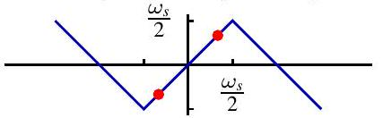

input frequency

$$\begin{aligned}
x(t) & =\cos \left(\omega_{0} t+\phi\right) \\
\omega_{0} & <\frac{1}{2} \omega_{s}
\end{aligned}$$

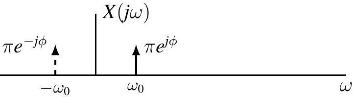

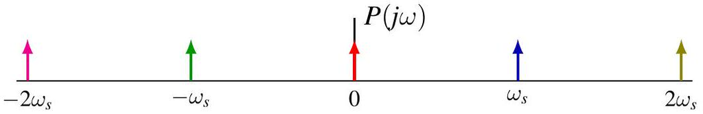

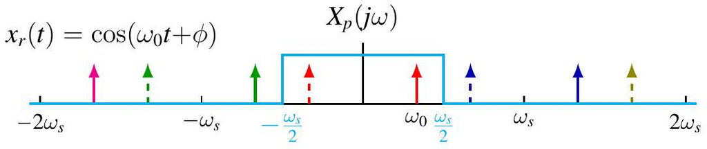

## 混叠

混叠 wraps frequencies

output frequency

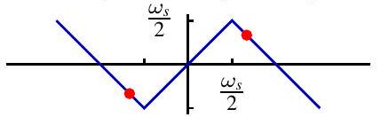

$$\begin{aligned}
& (t)=\cos \left(\omega_{0} t+\phi\right) \\
& \omega_{0}>\frac{1}{2} \omega_{s}
\end{aligned}$$

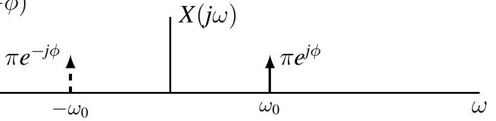

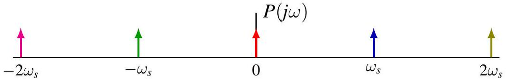

$$x_{r}(t)=\cos \left(\left(\omega_{s}-\omega_{0}\right) t-\phi\right) \quad X_{p}(j \omega)$$

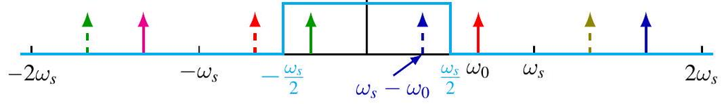

## 混叠

混叠 wraps frequencies

## output frequency

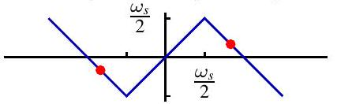

input frequency

$$\begin{aligned}
(t) & =\cos \left(\omega_{0} t+\phi\right) \\
\omega_{0} & >\frac{1}{2} \omega_{s} \pi e^{-j \phi}
\end{aligned}$$

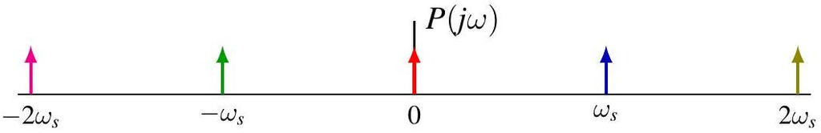

$$x_{r}(t)=\cos \left(\left(\omega_{s}-\omega_{0}\right) t-\phi\right) \quad X_{p}(j \omega)$$

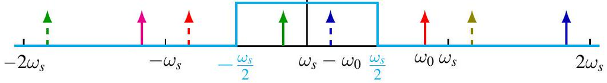

## 混叠

- $x(t)=\cos \left(\frac{5 \pi}{3} t\right), x[n]=\cos \left(\frac{5 \pi}{3} n\right)=\cos \left(\frac{\pi}{3} n\right)$
- $x_{r}(t)=\cos \left(\frac{\pi}{3} t\right)$

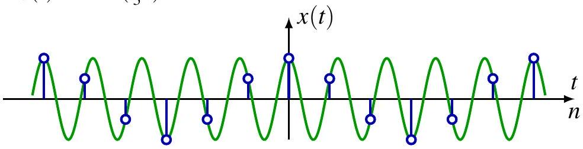

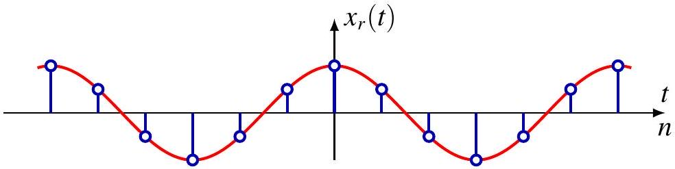

例： In movies, wheels often appear to rotate more slowly than they actually do and even in wrong direction

## 混叠

混叠 wraps frequencies

## output frequency

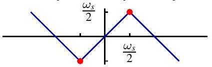

input frequency $x(t)=\cos \left(\omega_{0} t+\phi\right)$

$$\omega_{0}=\frac{1}{2} \omega_{s} \quad \pi e^{-j \phi}$$

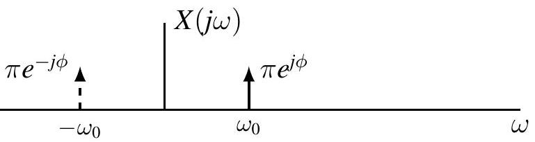

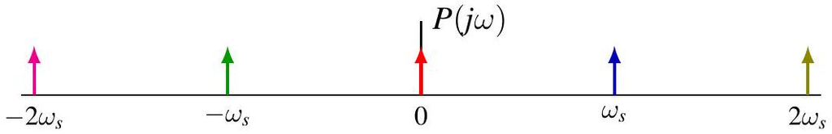

$$x_{r}(t)=(\cos \phi) \cos \left(\omega_{0} t\right)$$

$$X_{p}(j \omega)$$

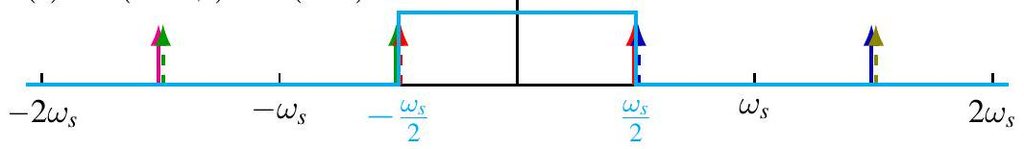

## 混叠

混叠 for more complex signals also wraps frequencies

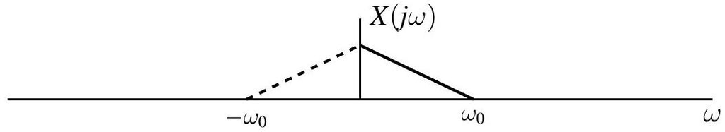

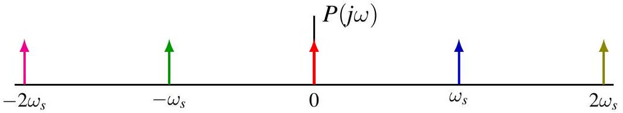

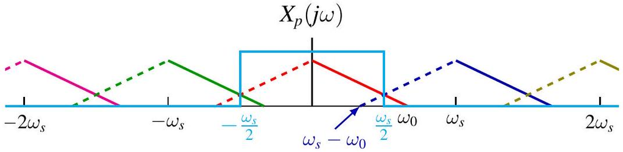

## 混叠

## 混叠 increases as sampling rate decreases

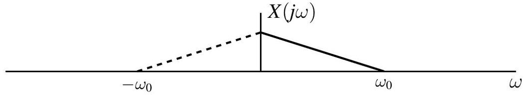

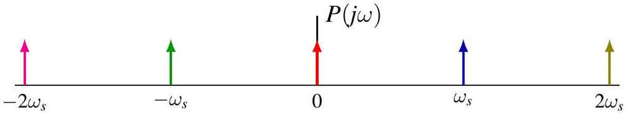

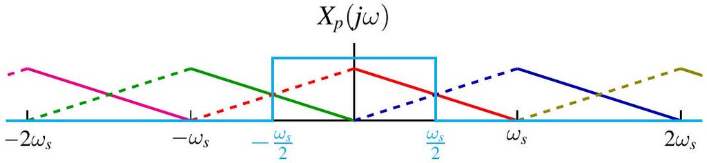

## 抗混叠滤波器

Filter out frequencies above $\frac{\omega_{s}}{2}$ before sampling

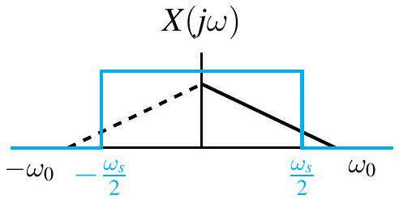

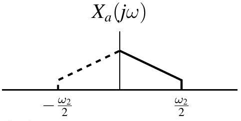

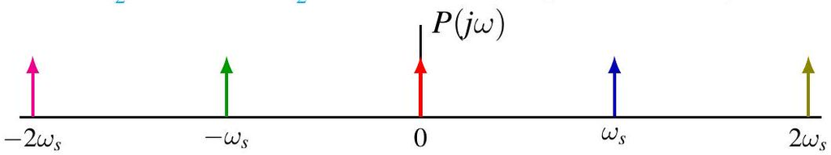

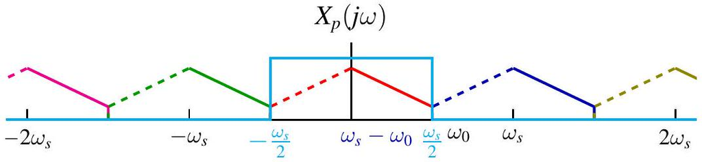

## 抗混叠滤波器

Filter out frequencies above $\frac{\omega_{s}}{2}$ before sampling

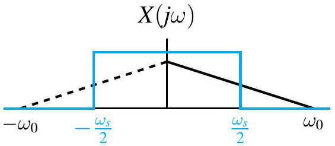

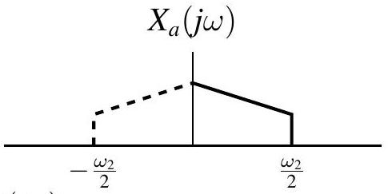

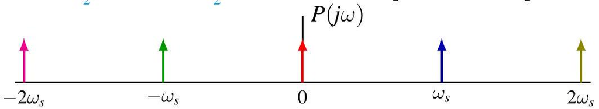

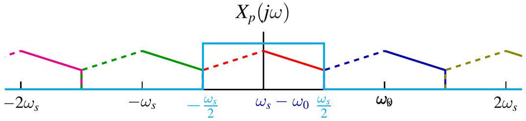

## DTFT 的卷积性质

$$(x * h)[n] \stackrel{\mathcal{F}}{\longleftrightarrow} X\left(e^{j \omega}\right) H\left(e^{j \omega}\right)$$

NB. Dual of multiplication property of CTFS

$$x(t) y(t) \stackrel{\mathcal{F S}}{\longleftrightarrow}(\hat{x} * \hat{y})[k]$$

NB. Similar to CTFT, applicable when formula is well-defined Proof.

$$\begin{aligned}
\mathcal{F}\{x * h\}\left(e^{j \omega}\right) & =\sum_{n \in \mathbb{Z}}(x * h)[n] e^{-j \omega n}=\sum_{n \in \mathbb{Z}} \sum_{m \in \mathbb{Z}} x[m] h[n-m] e^{-j \omega n} \\
& =\sum_{m \in \mathbb{Z}} x[m] \sum_{n \in \mathbb{Z}} h[n-m] e^{-j \omega n} \\
& =\sum_{m \in \mathbb{Z}} x[m] e^{-j \omega m} H\left(e^{j \omega}\right) \\
& =X\left(e^{j \omega}\right) H\left(e^{j \omega}\right)
\end{aligned}$$

## LTI 系统的频率响应

LTI system $T$

- fully characterized by impulse response $h$

$$y=T(x)=h * x$$

- also fully characterized by frequency response $H=\mathcal{F}\{h\}$, if $H$ is well-defined
- BIBO stable system, $h \in \ell_{1}$
- other systems: accumulator $h=u$, …

Typically, convolution property implies

$$Y=\mathcal{F}\{y\}=H X=\mathcal{F}\{h\} \mathcal{F}\{x\}$$

Instead of computing $x * h$, can do

$$y=\mathcal{F}^{-1}(\mathcal{F}\{h\} \mathcal{F}\{x\})$$

## 例

Response of LTI system with impulse response $h[n]=a^{n} u[n]$ to input $x[n]=b^{n} u[n]$, where $|a|<1,|b|<1$ 方法 1. Direct convolution $y=x * h$ 方法 2. Solve difference equation with initial rest condition

$$y[n]-a y[n-1]=b^{n} u[n]$$

方法 3. Fourier transform.

$$H=\frac{1}{1-a e^{-j \omega}}, X=\frac{1}{1-b e^{-j \omega}} \Longrightarrow Y=\frac{1}{\left(1-a e^{-j \omega}\right)\left(1-b e^{-j \omega}\right)}$$

If $a \neq b, Y\left(e^{j \omega}\right)=\frac{a /(a-b)}{1-a e^{-j \omega}}-\frac{b /(a-b)}{1-b e^{-j \omega}}, \quad y[n]=\frac{1}{a-b}\left(a^{n+1}-b^{n+1}\right) u[n]$ If $a=b, Y\left(e^{j \omega}\right)=\frac{d}{d a}\left(\frac{a}{1-a e^{-j \omega}}\right), y[n]=\frac{d}{d a} a^{n+1} u[n]=(n+1) a^{n} u[n]$ Or use $Y\left(e^{j \omega}\right)=\frac{j}{a} e^{j \omega} \frac{d}{d \omega}\left(\frac{a}{1-a e^{-j \omega}}\right)$ and differentiation property

## 例

Response of LTI system with impulse response $h[n]=a^{n} u[n]$ to input $x[n]=\cos \left(\omega_{0} n\right),|a|<1$. Frequency response

$$H\left(e^{j \omega}\right)=\frac{1}{1-a e^{-j \omega}}$$

方法 1. Use eigenfunction property

$$\begin{gathered}
x[n]=\frac{1}{2} e^{j \omega_{0} n}+\frac{1}{2} e^{-j \omega_{0} n} \\
y[n]=\frac{1}{2} H\left(e^{j \omega_{0}}\right) e^{j \omega_{0} n}+\frac{1}{2} H\left(e^{-j \omega_{0}}\right) e^{-j \omega_{0} n}=\operatorname{Re} \frac{e^{j \omega_{0} n}}{1-a e^{-j \omega_{0}}} \\
=\frac{1}{\sqrt{1-2 a \cos \omega_{0}+a^{2}}} \cos \left(\omega_{0} n-\arctan \frac{a \sin \omega_{0}}{1-a \cos \omega_{0}}\right)
\end{gathered}$$

## 例

方法 2. Use Fourier transform of $X$

$$\begin{aligned}
& X\left(e^{j \omega}\right)=\sum_{k=-\infty}^{\infty}\left[\pi \delta\left(\omega-\omega_{0}+2 k \pi\right)+\pi \delta\left(\omega+\omega_{0}+2 k \pi\right)\right] \\
& Y\left(e^{j \omega}\right)=\sum_{k=-\infty}^{\infty} \pi H\left(e^{j\left(\omega_{0}-2 k \pi\right)}\right) \delta\left(\omega-\omega_{0}+2 k \pi\right) \\
& \quad+\sum_{k=-\infty}^{\infty} \pi H\left(e^{-j\left(\omega_{0}+2 k \pi\right)}\right) \delta\left(\omega+\omega_{0}+2 k \pi\right) \\
& =H\left(e^{j \omega_{0}}\right) \sum_{k=-\infty}^{\infty} \pi \delta\left(\omega-\omega_{0}+2 k \pi\right) \\
& \quad+H\left(e^{-j \omega_{0}}\right) \sum_{k=-\infty}^{\infty} \pi \delta\left(\omega+\omega_{0}+2 k \pi\right) \\
& y[n]=\frac{1}{2} H\left(e^{j \omega_{0}}\right) e^{j \omega_{0} n}+\frac{1}{2} H\left(e^{-j \omega_{0}}\right) e^{-j \omega_{0} n}
\end{aligned}$$

## 例: Ideal Bandstop Filter

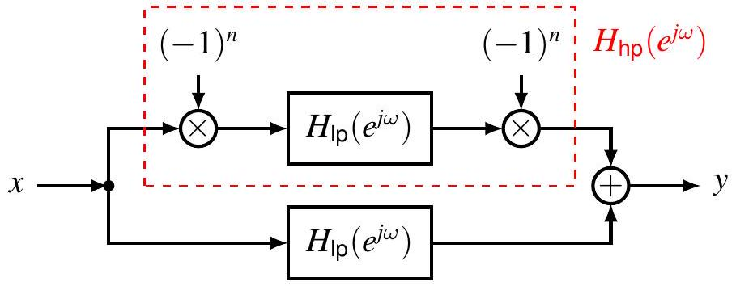

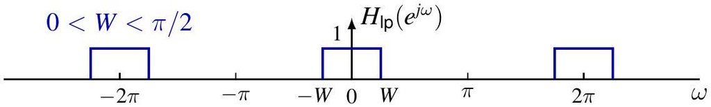

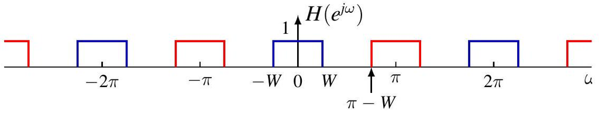

## 目录

1. DTFT 的卷积性质
2. DTFT 的乘积性质
3. 线性常系数差分方程描述的系统
4. 离散时间信号的采样
5. 连续时间信号的离散时间处理

## DTFT 的乘积性质

$$x[n] y[n] \stackrel{\mathcal{F}}{\longleftrightarrow} \frac{1}{2 \pi} X \circledast Y=\frac{1}{2 \pi} \int_{2 \pi} X\left(e^{j \theta}\right) Y\left(e^{j(\omega-\theta)}\right) d \theta$$

NB. Dual of periodic convolution property of CTFS

$$x \circledast y \stackrel{\mathcal{F S}}{\longleftrightarrow} T \hat{x} \hat{y}$$

Proof.

$$\begin{aligned}
\mathcal{F}\{x y\}\left(e^{j \omega}\right) & =\sum_{n \in \mathbb{Z}} x[n] y[n] e^{-j \omega n}=\sum_{n \in \mathbb{Z}}\left(\frac{1}{2 \pi} \int_{2 \pi} X\left(e^{j \theta}\right) e^{j \theta n} d \theta\right) y[n] e^{-j \omega n} \\
& =\frac{1}{2 \pi} \int_{2 \pi} X\left(e^{j \theta}\right)\left(\sum_{n \in \mathbb{Z}} y[n] e^{-j(\omega-\theta) n}\right) d \theta \\
& =\frac{1}{2 \pi} \int_{2 \pi} X\left(e^{j \theta}\right) Y\left(e^{j(\omega-\theta)}\right) d \theta
\end{aligned}$$

## 例

$$X=\frac{1}{2 \pi} X_{1} \underset{\uparrow}{\circledast} X_{2}=\frac{1}{2 \pi} \tilde{X}_{1} * X_{2}$$

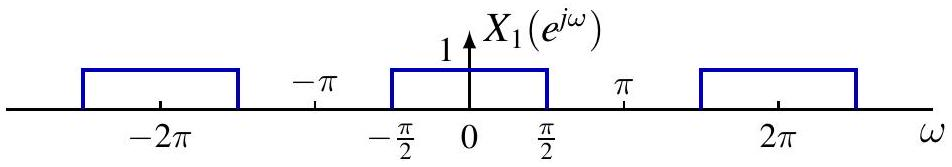

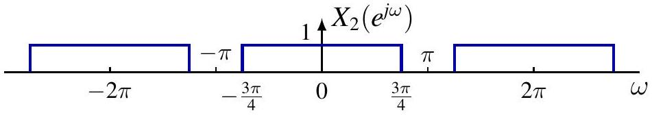

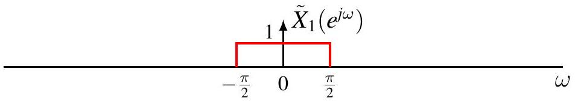

## 例

$x[n]=x_{1}[n] x_{2}[n]$, where $x_{1}[n]=\frac{\sin (3 \pi n / 4)}{\pi n}, x_{2}[n]=\frac{\sin (\pi n / 2)}{\pi n}$

$$X=\frac{1}{2 \pi} X_{1} \underset{\uparrow}{\circledast} X_{2}=\frac{1}{2 \pi} \tilde{X}_{1} * X_{2}=\frac{1}{2 \pi} \sum_{k=-\infty}^{\infty} \underset{\substack{\uparrow \\ \text { periodic }}}{\tau_{2 k \pi}\left(\tilde{X}_{1} * \tilde{X}_{2}\right)} \text { aperiodic }$$

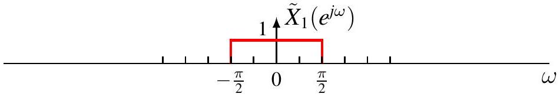

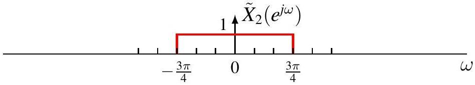

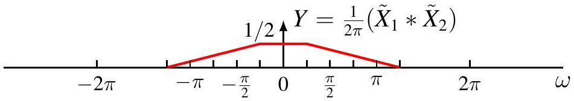

## 例

$x[n]=x_{1}[n] x_{2}[n]$, where $x_{1}[n]=\frac{\sin (3 \pi n / 4)}{\pi n}, x_{2}[n]=\frac{\sin (\pi n / 2)}{\pi n}$

$$X=\frac{1}{2 \pi} X_{1} \circledast X_{2}=\frac{1}{2 \pi} \tilde{X}_{1} * X_{2}=\frac{1}{2 \pi} \sum_{k=-\infty}^{\infty} \underset{\substack{\uparrow \\ \text { periodic }}}{\tau_{2 k \pi}\left(\tilde{X}_{1} * \tilde{X}_{2}\right)} \text { aperiodic }$$

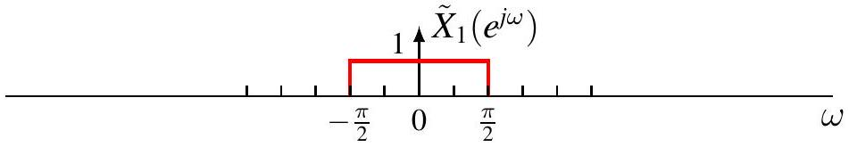

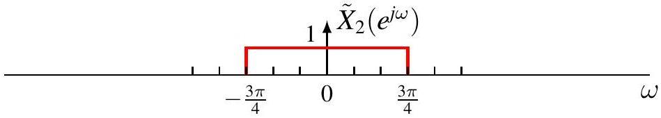

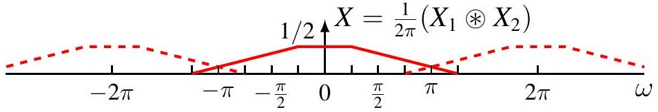

## 例

$x[n]=x_{1}[n] x_{2}[n]$, where $x_{1}[n]=\frac{\sin (3 \pi n / 4)}{\pi n}, x_{2}[n]=\frac{\sin (\pi n / 2)}{\pi n}$

$$X=\frac{1}{2 \pi} X_{1} \circledast X_{2}=\frac{1}{2 \pi} \tilde{X}_{1} * X_{2}=\frac{1}{2 \pi} \sum_{k=-\infty}^{\infty} \underset{\substack{\uparrow \\ \text { periodic }}}{\tau_{2 k \pi}\left(\tilde{X}_{1} * \tilde{X}_{2}\right)} \text { aperiodic }$$

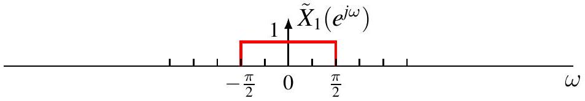

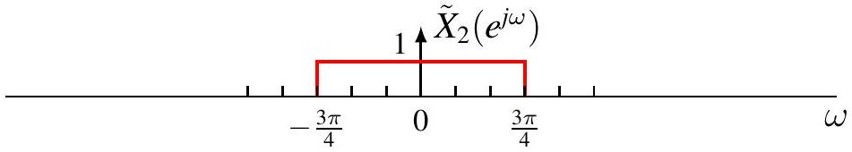

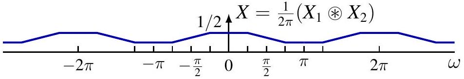

## 例: DT Modulation

$$y[n]=x[n] c[n], \text { where } c[n]=\cos \left(\omega_{c} n\right)$$

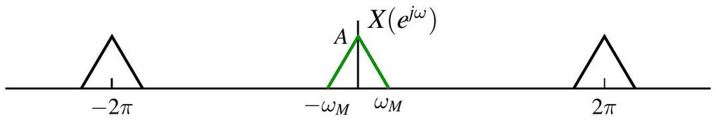

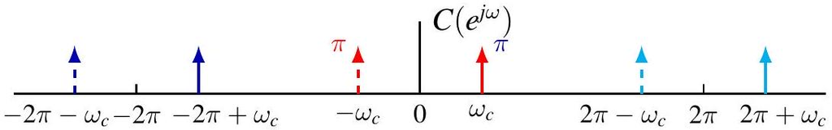

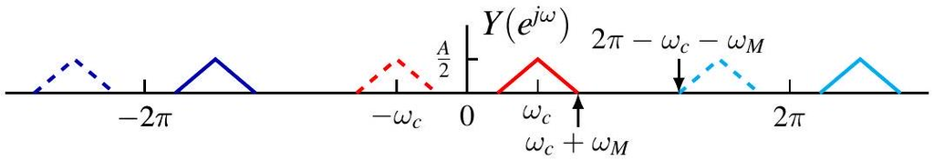

No overlap between replicas: $\left\{\begin{array}{l}\omega_{c}>\omega_{M} \\ \omega_{c}+\omega_{M}<\pi\end{array} \quad \Longrightarrow \omega_{M}<\frac{\pi}{2}\right.$

## 例: DT Demodulation

$$z[n]=y[n] c[n], \text { where } c[n]=\cos \left(\omega_{c} n\right)$$

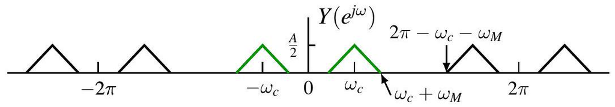

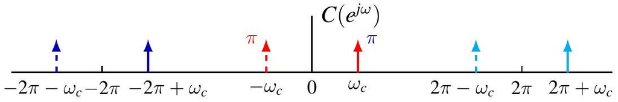

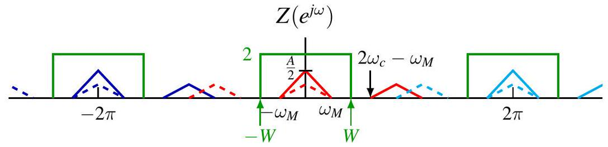

Recover $X$ by lowpass filtering $Y$ with $W \in\left(\omega_{M}, 2 \omega_{c}-\omega_{M}\right)$

## 目录

1. DTFT 的卷积性质
2. DTFT 的乘积性质
3. 线性常系数差分方程描述的系统
4. 离散时间信号的采样
5. 连续时间信号的离散时间处理

## Linear Constant-coefficient Difference Equations

Frequency response of LTI system described by

$$\sum_{k=0}^{N} a_{k} y[n-k]=\sum_{k=0}^{M} b_{k} x[n-k]$$

方法 1. Use eigenfunction property

$$x[n]=e^{j \omega n} \Longrightarrow y[n]=H\left(e^{j \omega}\right) e^{j \omega n}$$

Substitution into difference equation yields

$$\begin{gathered}
\sum_{k=0}^{N} a_{k} H\left(e^{j \omega}\right) e^{j \omega(n-k)}=\sum_{k=0}^{M} b_{k} e^{j \omega(n-k)} \\
H\left(e^{j \omega}\right)=\frac{\sum_{k=0}^{M} b_{k} e^{-j \omega k}}{\sum_{k=0}^{N} a_{k} e^{-j \omega k}}
\end{gathered}$$

## Linear Constant-coefficient Difference Equations

方法 2. Take Fourier transform of both sides

$$\mathcal{F}\left\{\sum_{k=0}^{N} a_{k} y[n-k]\right\}=\mathcal{F}\left\{\sum_{k=0}^{M} b_{k} x[n-k]\right\}$$

By linearity and time-shifting property

$$\sum_{k=0}^{N} a_{k} e^{-j \omega k} Y\left(e^{j \omega}\right)=\sum_{k=0}^{M} b_{k} e^{-j \omega k} X\left(e^{j \omega}\right)$$

By convolution property

$$H\left(e^{j \omega}\right)=\frac{Y\left(e^{j \omega}\right)}{X\left(e^{j \omega}\right)}=\frac{\sum_{k=0}^{M} b_{k} e^{-j \omega k}}{\sum_{k=0}^{N} a_{k} e^{-j \omega k}}$$

Frequency response is rational function of $e^{-j \omega}$

## 例

Consider LTI system described by

$$y[n]-\frac{3}{4} y[n-1]+\frac{1}{8} y[n-2]=2 x[n]$$

Frequency response

$$H\left(e^{j \omega}\right)=\frac{2}{1-\frac{3}{4} e^{-j \omega}+\frac{1}{8} e^{-j 2 \omega}}$$

By partial fraction expansion

$$H\left(e^{j \omega}\right)=\frac{2}{\left(1-\frac{1}{2} e^{-j \omega}\right)\left(1-\frac{1}{4} e^{-j \omega}\right)}=\frac{4}{1-\frac{1}{2} e^{-j \omega}}-\frac{2}{1-\frac{1}{4} e^{-j \omega}}$$

Take inverse Fourier transform to obtain impulse response

$$h[n]=4\left(\frac{1}{2}\right)^{n} u[n]-2\left(\frac{1}{4}\right)^{n} u[n]$$

## 例

Find response to $x[n]=\left(\frac{1}{4}\right)^{n} u[n]$. Fourier transform of response

$$Y\left(e^{j \omega}\right)=H\left(e^{j \omega}\right) X\left(e^{j \omega}\right)=\frac{2}{\left(1-\frac{1}{2} e^{-j \omega}\right)\left(1-\frac{1}{4} e^{-j \omega}\right)} \cdot \frac{1}{1-\frac{1}{4} e^{-j \omega}}$$

By partial fraction expansion

$$Y\left(e^{j \omega}\right)=-\frac{4}{1-\frac{1}{4} e^{-j \omega}}-\frac{2}{\left(1-\frac{1}{4} e^{-j \omega}\right)^{2}}+\frac{8}{1-\frac{1}{2} e^{-j \omega}}$$

Take inverse Fourier transform to obtain response

$$y[n]=\left\{-4\left(\frac{1}{4}\right)^{n}-2(n+1)\left(\frac{1}{4}\right)^{n}+8\left(\frac{1}{2}\right)^{n}\right\} u[n]$$

## 部分分式展开

$$H\left(e^{j \omega}\right)=\frac{2}{1-\frac{3}{4} e^{-j \omega}+\frac{1}{8} e^{-j 2 \omega}}$$

Replace $e^{-j \omega}$ by $z$,

$$\begin{gathered}
H\left(z^{-1}\right)=\frac{2}{1-\frac{3}{4} z+\frac{1}{8} z^{2}}=\frac{2}{\left(1-\frac{1}{2} z\right)\left(1-\frac{1}{4} z\right)}=\frac{A}{1-\frac{1}{2} z}+\frac{B}{1-\frac{1}{4} z} \\
A=\left.\left[\left(1-\frac{1}{2} z\right) H\left(z^{-1}\right)\right]\right|_{z=2}=\left.\frac{2}{1-\frac{1}{4} z}\right|_{z=2}=4 \\
B=\left.\left[\left(1-\frac{1}{4} z\right) H\left(z^{-1}\right)\right]\right|_{z=4}=\left.\frac{2}{1-\frac{1}{2} z}\right|_{z=4}=-2
\end{gathered}$$

NB. Terms take form $\frac{A}{(s-r)^{m}}$ for CT, but $\frac{A}{(1-r z)^{m}}$ for DT

## 部分分式展开

$$Y\left(e^{j \omega}\right)=\frac{2}{\left(1-\frac{1}{2} e^{-j \omega}\right)\left(1-\frac{1}{4} e^{-j \omega}\right)} \cdot \frac{1}{1-\frac{1}{4} e^{-j \omega}}$$

Replace $e^{-j \omega}$ by $z$,

$$Y\left(z^{-1}\right)=\frac{2}{\left(1-\frac{1}{2} z\right)\left(1-\frac{1}{4} z\right)^{2}}=\frac{A_{1,1}}{1-\frac{1}{2} z}+\frac{A_{2,1}}{1-\frac{1}{4} z}+\frac{A_{2,2}}{\left(1-\frac{1}{4} z\right)^{2}}$$

To find $A_{1,1}$

1. Multiply both side by $1-\frac{1}{2} z$,

$$\left(1-\frac{1}{2} z\right) Y\left(z^{-1}\right)=\frac{2}{\left(1-\frac{1}{4} z\right)^{2}}=A_{1,1}+\frac{A_{2,1}\left(1-\frac{1}{2} z\right)}{1-\frac{1}{4} z}+\frac{A_{2,2}\left(1-\frac{1}{2} z\right)}{\left(1-\frac{1}{4} z\right)^{2}}$$

2. Evaluate at $z=2$, i.e. root of $1-\frac{1}{2} z=0$

$$A_{1,1}=\left.\left[\left(1-\frac{1}{2} z\right) Y\left(z^{-1}\right)\right]\right|_{z=2}=\left.\frac{2}{\left(1-\frac{1}{4} z\right)^{2}}\right|_{z=2}=8$$

## 部分分式展开

$$Y\left(z^{-1}\right)=\frac{2}{\left(1-\frac{1}{2} z\right)\left(1-\frac{1}{4} z\right)^{2}}=\frac{A_{1,1}}{1-\frac{1}{2} z}+\frac{A_{2,1}}{1-\frac{1}{4} z}+\frac{A_{2,2}}{\left(1-\frac{1}{4} z\right)^{2}}$$

To find $A_{2,2}$

1. Multiply both side by $\left(1-\frac{1}{4} z\right)^{2}$,

$$\left(1-\frac{1}{4} z\right)^{2} Y\left(z^{-1}\right)=\frac{2}{1-\frac{1}{2} z}=\frac{A_{1,1}\left(1-\frac{1}{4} z\right)^{2}}{1-\frac{1}{2} z}+A_{2,1}\left(1-\frac{1}{4} z\right)+A_{2,2}$$

2. Evaluate at $z=4$, i.e. root of $1-\frac{1}{4} z=0$

$$A_{2,2}=\left.\left[\left(1-\frac{1}{4} z\right)^{2} Y\left(z^{-1}\right)\right]\right|_{z=4}=\left.\frac{2}{1-\frac{1}{2} z}\right|_{z=4}=-2$$

## 部分分式展开

$$Y\left(z^{-1}\right)=\frac{2}{\left(1-\frac{1}{2} z\right)\left(1-\frac{1}{4} z\right)^{2}}=\frac{A_{1,1}}{1-\frac{1}{2} z}+\frac{A_{2,1}}{1-\frac{1}{4} z}+\frac{A_{2,2}}{\left(1-\frac{1}{4} z\right)^{2}}$$

To find $A_{2,1}$

1. Multiply both side by $\left(1-\frac{1}{4} z\right)^{2}$,

$$\left(1-\frac{1}{4} z\right)^{2} Y\left(z^{-1}\right)=\frac{2}{1-\frac{1}{2} v}=\frac{A_{1,1}\left(1-\frac{1}{4} z\right)^{2}}{1-\frac{1}{2} z}+A_{2,1}\left(1-\frac{1}{4} z\right)+A_{2,2}$$

2. Differentiate both sides

$$\frac{d}{d z}\left(1-\frac{1}{4} z\right)^{2} Y\left(z^{-1}\right)=\frac{1}{\left(1-\frac{1}{2} z\right)^{2}}=\frac{d}{d z} \frac{A_{1,1}\left(1-\frac{1}{4} z\right)^{2}}{1-\frac{1}{2} z}+\left(-\frac{\mathbf{1}}{\mathbf{4}}\right) A_{2,1}$$

3. Evaluate at $z=4$, i.e. root of $1-\frac{1}{4} z=0$

$$A_{2,1}=\left.(-4)\left[\frac{d}{d z}\left(1-\frac{1}{4} z\right)^{2} Y\left(z^{-1}\right)\right]\right|_{z=4}=\left.\frac{-4}{\left(1-\frac{1}{2} z\right)^{2}}\right|_{z=4}=-4$$

## 逆傅里叶变换 of $\frac{1}{\left(1-a e^{-j \omega}\right)^{n}}$

Recall

$$a^{n} u[n] \stackrel{\mathcal{F}}{\longleftrightarrow} \frac{1}{1-a e^{-j \omega}}, \quad|a|<1$$

i.e.

$$\frac{1}{1-a z}=\sum_{n=0}^{\infty} a^{n} z^{n}, \quad z=e^{-j \omega}$$

Differentiate $m-1$ times w.r.t. $z$

$$\frac{(m-1)!a^{m-1}}{(1-a z)^{m}}=\sum_{n=m-1}^{\infty} a^{n} \frac{n!}{(n-m+1)!} z^{n-(m-1)}$$

$$\frac{1}{(1-a z)^{m}}=\sum_{n=m-1}^{\infty} a^{n-m+1}\binom{n}{m-1} z^{n-m+1}=\sum_{n=0}^{\infty} a^{n}\binom{n+m-1}{m-1} z^{n}$$

Thus

$$\binom{n+m-1}{n} a^{n} u[n] \stackrel{\mathcal{F}}{\longleftrightarrow} \frac{1}{\left(1-a e^{-j \omega}\right)^{m}}$$

## 目录

1. DTFT 的卷积性质
2. DTFT 的乘积性质
3. 线性常系数差分方程描述的系统
4. 离散时间信号的采样
5. 连续时间信号的离散时间处理

## 冲激列采样

DT signal $x[n]$

DT impulse train

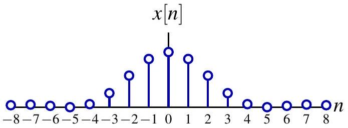

$$p[n]=\sum_{k=-\infty}^{\infty} \delta[n-k N]$$

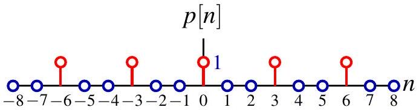

$$\begin{aligned}
& \text { Sampled signal } \\
& \begin{aligned}
x_{p}[n] & =x[n] p[n] \\
& =\sum_{k=-\infty}^{\infty} x[k N] \delta[n-k N]
\end{aligned}
\end{aligned}$$

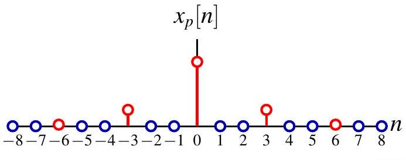

## 冲激列采样

Spectrum of impulse train

$$P\left(e^{j \omega}\right)=\omega_{s} \sum_{k=-\infty}^{\infty} \delta\left(\omega-k \omega_{s}\right), \quad \omega_{s}=\frac{2 \pi}{N}$$

Spectrum of sampled signal

$$X_{p}=\frac{1}{2 \pi} X \circledast P=\frac{1}{2 \pi} \tilde{X} * P=\frac{1}{2 \pi} X * \tilde{P}$$

where $\tilde{X}, \tilde{P}$ are respective parts of $X, P$ within one period of $2 \pi$

$$X_{p}\left(e^{j \omega}\right)=\frac{1}{N} \sum_{k=-\infty}^{\infty} \tilde{X}\left(e^{j\left(\omega-k \omega_{s}\right)}\right)=\frac{1}{N} \sum_{k=0}^{N-1} X\left(e^{j\left(\omega-k \omega_{s}\right)}\right)$$

## 冲激列采样

First view: Replicating $\tilde{X}$ at $k \omega_{s}$ for $k \in \mathbb{Z}$

$$X_{p}\left(e^{j \omega}\right)=\frac{1}{N} \sum_{k=-\infty}^{\infty} \tilde{X}\left(e^{j\left(\omega-k \omega_{s}\right)}\right)$$

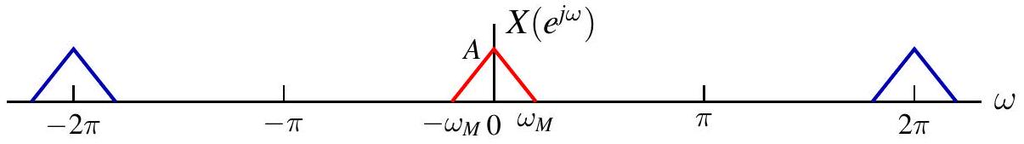

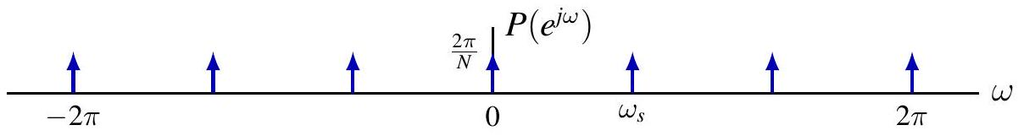

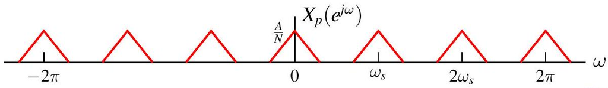

## 冲激列采样

Second view: Replicating $X$ at $k \omega_{s}$ for $k=0,1, \ldots, N-1$

$$X_{p}\left(e^{j \omega}\right)=\frac{1}{N} \sum_{k=0}^{N-1} X\left(e^{j\left(\omega-k \omega_{s}\right)}\right)$$

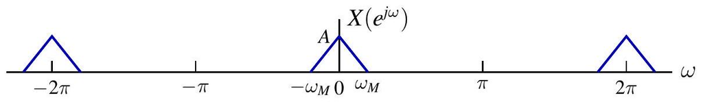

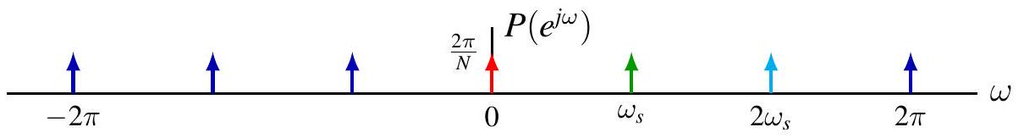

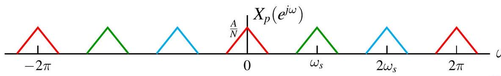